# Advanced plotting options in biogrowth

```r
library(biogrowth)
library(tidyverse)
library(cowplot)
```

This vignette gives further detail on how to use the functions in **biogrowth** to prepare publication ready figures. For details on how to use the base functions of the package, please check the vignettes for model fitting and growth predictions.

The functions in **biogrowth** use `cowplot::theme_cowplot` as default, that has a nice clean theme and could be used in a publication as is. However, more control over formatting options can be needed in order to standardize plots or when preparing figures for a specific journal.

Moreover, every plot is based on **ggplot2**, and therefore the plots can be manipulated in the same way. In order to ease manipulation, plotting methods in **biogrowth** include arguments to control the aesthetics that would often would within the “geom_” definition (such as `colour`, `size` or `linetype`).

As an illustration for this, we will use a growth model fitted to data under dynamic environmental conditions.

```r
data("example_dynamic_growth")
data("example_env_conditions")

sec_models <- list(temperature = "CPM", aw = "CPM")

known_pars <- list(Nmax = 1e4,  # Primary model
                   N0 = 1e0, Q0 = 1e-3,  # Initial values of the primary model
                   mu_opt = 4, # mu_opt of the gamma model
                   temperature_n = 1,  # Secondary model for temperature
                   aw_xmax = 1, aw_xmin = .9, aw_n = 1  # Secondary model for water activity
                   )
my_start <- list(temperature_xmin = 25, temperature_xopt = 35,
                 temperature_xmax = 40, aw_xopt = .95)

my_model <- fit_growth(example_dynamic_growth,
                       sec_models,
                       my_start, known_pars,
                       environment = "dynamic",
                       env_conditions = example_env_conditions
                       )
```

By default, the S3 `plot()` methods use the `cowplot::theme_cowplot`

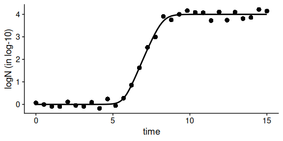

```r
plot(my_model)
```

As mentioned, the plot methods include a large list of additional arguments that can be used to edit the aesthetics of the plot. A whole list of arguments is available from the class documentation (e.g. accessible by typing `?GrowthFit` in the console). In the case of `plot.GrowthFit()`, the plot method includes the following arguments:

- `add_factor`
- `line_col`
- `line_size`
- `line_type`
- `point_col`
- `point_size`
- `point_shape`
- `ylims`
- `label_y1`
- `label_y2`
- `label_x`
- `line_col2`
- `line_size2`
- `line_type2`

This provides plenty of options to edit the aesthetics of the plot. For instance:

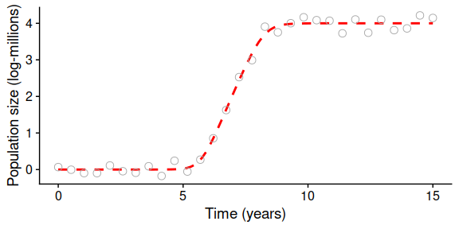

```r
plot(my_model,
     line_col = "red",
     line_size = 1,
     line_type  = "dashed",
     label_y1 = "Population size (log-millions)",
     label_x = "Time (years)",
     point_size = 3,
     point_shape = 1,
     point_col = "darkgrey")
```

Note that the plot function returns an instance of `ggplot`. This allows further editing of the plot using layers with the functions included in **ggplot2**. This provides plenty of options to edit the plot

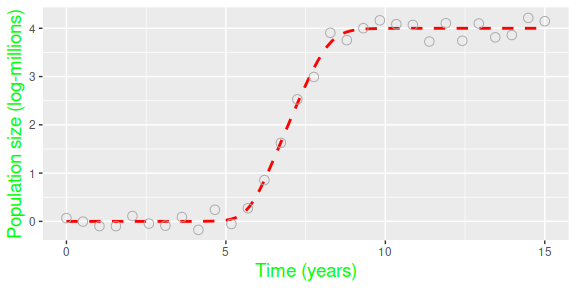

```r
plot(my_model,
     line_col = "red",
     line_size = 1,
     line_type  = "dashed",
     label_y1 = "Population size (log-millions)",
     label_x = "Time (years)",
     point_size = 3,
     point_shape = 1,
     point_col = "darkgrey") +
  theme_gray() +
  theme(axis.title = element_text(colour = "green", size = 14))
```

In some cases, the automatic scaling that ggplot2 uses might not be optimal. We can use the coord_cartesian() function to change the limits of the x- and y-axis

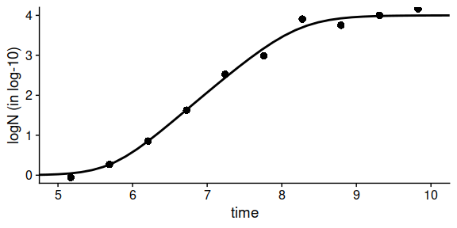

```r
plot(my_model) +
  coord_cartesian(xlim = c(5, 10), ylim = c(0, 4)) # changing the axis limits
```

## Combining plots into subplots

The `plot_grid()` function from **cowplot** provides a convenient way to combine different plots into a grid. For instance,

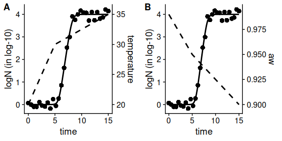

```r
p1 <- plot(my_model, add_factor = "temperature")
p2 <- plot(my_model, add_factor = "aw")
plot_grid(p1, p2, labels = "AUTO")
```

## Saving and reshaping plots

`ggsave()` will automatically save the last plot to a specified location. It needs a filename as a string, for instance “static_prediction.pdf” to save the figure as a pdf. It also needs a location to save to (defaults to the working directory), and optionally the user can set dimentions and units.

```r
# We save the plot as p1, notice that it does not get drawn now
p1 <- plot(my_model, line_col = "red")

# We save P1 as .pdf, as a 20x 20 cm square
# ggsave("static_prediction.pdf", p1, width = 20, height = 20, units = "cm")
```

# Full manual control

The classes `GrowthFit`, `GrowthPrediction` and `GlobalGrowthFit` are a subclass of `list`. This provides simple access to several attributes of the model. For instance, the the entry `best_prediction` of an instance of `GrowthFit` includes an instance of `GrowthPrediction` with the fitted model.

```r
my_model$best_prediction
```

```
#> Growth prediction under dynamic environmental conditions
#>
#> Environmental factors included: temperature, aw
#>
#> Parameters of the Baranyi primary model:
#> mu_opt   Nmax     N0     Q0
#>  4e+00  1e+04  1e+00  1e-03
#>
#> Parameter mu defined in log-10 scale
#>
#> Population size defined in log-10 scale
#>
#> Secondary model for temperature:
#>               xmin               xopt               xmax                  n
#> "26.6667032815958" "38.8653415561503" "70.3684359647904"                "1"
#>              model
#>              "CPM"
#>
#> Secondary model for aw:
#>                xmin                xopt                xmax                   n
#>               "0.9" "0.985185030452571"                 "1"                 "1"
#>               model
#>               "CPM"
```

In a similar way, the `simulation` entry of this instance includes a tibble with the model simulation

```r
head(my_model$best_prediction$simulation)
```

```
#> # A tibble: 6 × 4
#>    time     Q     N  logN
#>   <dbl> <dbl> <dbl> <dbl>
#> 1 0     0.001     1     0
#> 2 0.152 0.001     1     0
#> 3 0.303 0.001     1     0
#> 4 0.455 0.001     1     0
#> 5 0.606 0.001     1     0
#> 6 0.758 0.001     1     0
```

This allows making plots directly using this data using **ggplot2** (or similar packages)

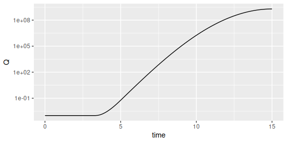

```r
ggplot(my_model$best_prediction$simulation) +
  geom_line(aes(x = time, y = Q)) +
  scale_y_log10()
```